# 02Python Essential

## Introductory

- We’re now ready to start learning the Python language itself, and the next few lectures are devoted to this task
- Our approach is aimed at those who already have at least some knowledge of fundamental programming concepts, such as
  - variables
  - for loops, while loops
  - conditionals (if/else)

## Introductory

- If you have no programming experience, you just need to cover some of the fundamentals of programming before returning here.
- Good references for first time programmers include:
  - The first 5 or 6 chapters of How to Think Like a Computer Scientist
  - Automate the Boring Stuff with Python
  - The start of Dive into Python 3

## First Example

- To begin, let’s suppose that we want to simulate and plot the white noise process $\epsilon_0,\epsilon_1,...,\epsilon_T$ where each draw $\epsilon_t$ is independent standard normal.
- In other words, we want to generate figures that look something like this:

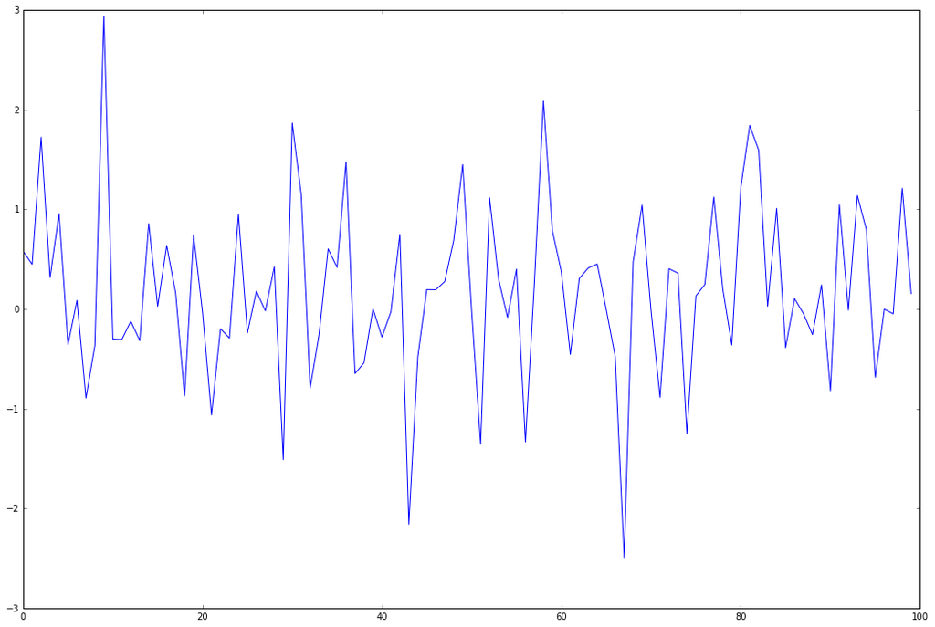

```python
%matplotlib inline
from matplotlib import rcParams
rcParams['figure.figsize'] = (18, 12)
from random import normalvariate
import matplotlib.pyplot as plt
ts_length = 100
epsilon_values = []   # An empty list
for i in range(ts_length):
    e = normalvariate(0, 1)
    epsilon_values.append(e)
plt.plot(epsilon_values, 'b-')
plt.show()
```

```python
from random import normalvariate
import matplotlib.pyplot as plt
ts_length = 100
epsilon_values = []   # An empty list
for i in range(ts_length):
    e = normalvariate(0, 1)
    epsilon_values.append(e)
plt.plot(epsilon_values, 'b-')
plt.show()
```

## First Example

- In brief,
  - Lines 1–2 use the Python `import` keyword to pull in functionality from external libraries
  - Line 3 sets the desired length of the time series
  - Line 4 creates an empty list called epsilon_values that will store the $\epsilon_t$ values as we generate them
  - Line 5 tells the Python interpreter that it should cycle through the block of indented lines (lines 6–7) ts_length times before continuing to line 8
  - Lines 6–7 draw a new value $\epsilon_t$ and append it to the end of the list epsilon_values
  - Lines 8–9 generate the plot and display it to the user

## Import Statements

- Consider the line `from random import normalvariate`
- Here `random` is a module, which is just a file containing Python code
- The statement `from random import normalvariate` causes the Python interpreter to
  - run the code in a file called `random.py` that was placed in your filesystem when you installed Python
  - make the function `normalvariate` defined in that file available for use in your program

## Import Statements

- If you want to import more attributes you can use a comma separated list, like so:

```python
from random import normalvariate, uniform
normalvariate(0, 1)
```

```python
uniform(-1, 1)
```

## Import Statements

- Alternatively, you can use the following syntax:

```python
import random
random.normalvariate(0, 1)
```

```python
random.uniform(-1, 1)
```

## Packages

- Now consider the line `import matplotlib.pyplot as plt`
- Here `matplotlib` is a Python package, and `pyplot` is a subpackage of `matplotlib`
- Packages are used when a developer wants to organize a number of Python files (modules) containing related code
- A package is just a directory containing files containing Python code

## Packages

- By definition, a package always contains a file called `__init__.py` that specifies what code will be run when we type import package_name
- Subpackages are the same, except that they are subdirectories of a package directory
- So `import matplotlib.pyplot as plt` runs the `__init__.py` file in the directory `matplotlib/pyplot` and makes the attributes specified in that file available to us
- The keyword as in `import matplotlib.pyplot as plt` just lets us access these attributes via as simpler name

## Lists

- Next let’s consider the statement `epsilon_values = []`, which creates an empty list
- Lists are a native Python data structure used to group a collection of objects.

```python
x = [10, 'foo', False]  # We can include heterogeneous data inside a list
type(x)
```

## Lists

- Here the first element of `x` is an integer, the next is a string and the third is a Boolean value
- When adding a value to a list, we can use the syntax `list_name.append(some_value)`

```python
x
```

```python
x.append(2.5)
x
```

## Lists

- Here `append()` is what’s called a *method*, which is a function “attached to” an object-in this case, the list x
- We’ll learn all about methods later on, but just to give you some idea,
  - Python objects such as lists, strings, etc. all have methods that are used to manipulate the data contained in the object
  - String objects have string methods, list objects have list methods, etc.

## Lists

- Another useful list method is pop()

```python
x.pop()
```

```python
x
```

## Lists

- Following C, C++, Java, etc., lists in Python are zero based

```python
x[0]
```

```python
x[1]
```

## Lists

- Returning to the program above, we actually create a second list besides epsilon_values
- In particular, line 5 calls the range() function, which creates sequential lists of integers

```python
range(4)
```

```python
range(5)
```

## The for loop

- Now let’s consider the `for` loop in `test_program_1.py`, which we repeat here for convenience, along with the line that follows it

```python
for i in range(ts_length):
    e = normalvariate(0, 1)
    epsilon_values.append(e)
plt.plot(epsilon_values, 'b-')
plt.show()
```

## The for loop

- The `for` loop causes Python to execute the two indented lines a total of `ts_length` times before moving on
- These two lines are called a code block, since they comprise the “block” of code that we are looping over
- Unlike most other languages, Python knows the extent of the code block *only from indentation*
- In particular, the fact that indentation decreases after line `epsilon_values.append(e)` tells Python that this line marks the lower limit of the code block

```python
animals = ['dog', 'cat', 'bird']
for animal in animals:
    print("The plural of " + animal + " is " + animal + "s")
```

## The for loop

- This example helps to clarify how the `for` loop works: When we execute a loop of the form

```
for variable_name in sequence:
    <code block>
```

- The Python interpreter performs the following:
  - For each element of sequence, it “binds” the name `variable_name` to that element and then executes the code block
- The `sequence` object can in fact be a very general object, as we’ll see soon enough

## Code Blocks and Indentation

- In discussing the for loop, we explained that the code blocks being looped over are delimited by indentation
- In fact, in Python all code blocks (i.e., those occuring inside loops, if clauses, function definitions, etc.) are delimited by indentation
- Thus, unlike most other languages, whitespace in Python code affects the output of the program
- Once you get used to it, this is a very good thing because it
  - forces clean, consistent indentation, which improves readability
  - removes clutter, such as the brackets or end statements used in other languages

## Code Blocks and Indentation

- On the other hand, it takes a bit of care to get right, so please remember:
  - The line before the start of a code block always ends in a colon
  - All lines in a code block must have the same amount of indentation
  - The Python standard is 4 spaces, and that’s what you should use

## Tabs vs Spaces

- One small “gotcha” here is the mixing of tabs and spaces (Important: Within text files, the internal representation of tabs and spaces is not the same)
- You can use your Tab key to insert 4 spaces, but you need to make sure it’s configured to do so
- If you are using the IPython notebook you will have no problems here (Also, good quality text editors will allow you to configure the Tab key to insert spaces instead of tabs - trying searching on line)

## while loops

- The `for` loop is the most common technique for iteration in Python
- But, for the purpose of illustration, let’s modify `test_program_1.py` to use a `while` loop instead
- In Python, the while loop syntax is as shown in the file `test_program_2.py` below

```python
from random import normalvariate
import matplotlib.pyplot as plt
ts_length = 100
epsilon_values = []
i = 0
while i < ts_length:
    e = normalvariate(0, 1)
    epsilon_values.append(e)
    i = i + 1
plt.plot(epsilon_values, 'b-')
plt.show()
```

## while loops

- The output of `test_program_2.py` is identical to `test_program_1.py` above
- Comments:
  - The code block for the while loop is lines 7–9, again delimited only by indentation
  - The statement `i = i + 1` can be replaced by `i += 1`

## User-Defined Functions

- Now let’s go back to the `for` loop, but restructure our program to make the logic clearer
- To this end, we will break our program into two parts:
  - A user-defined function that generates a list of random variables
  - The main part of the program that
    - calls this function to get data
    - plots the data
- This is accomplished in `test_program_3.py`

```python
from random import normalvariate
import matplotlib.pyplot as plt
def generate_data(n):
    epsilon_values = []
    for i in range(n):
        e = normalvariate(0, 1)
        epsilon_values.append(e)
    return epsilon_values
data = generate_data(100)
plt.plot(data, 'b-')
plt.show()
```

## User-Defined Functions

- Let’s go over this carefully, in case you’re not familiar with functions and how they work
- We have defined a function called `generate_data()`, where the definition spans lines 3–8

## User-Defined Functions

- `def` on line 3 is a Python keyword used to start function definitions
- `def generate_data(n):` indicates that the function is called `generate_data`, and that it has a single argument n
- Lines 4–8 are a code block called the *function body*-in this case it creates an iid list of random draws using the same logic as before
- Line 8 indicates that the list `epsilon_values` is the object that should be returned to the calling code

## Conditions

- Our function `generate_data()` is rather limited
- Let’s make it slightly more useful by giving it the ability to return either standard normals or uniform random variables on (0,1) as required
- This is achieved in `test_program_4.py` by adding the argument `generator_type` to `generate_data()`

```python
from random import normalvariate, uniform
import matplotlib.pyplot as plt
def generate_data(n, generator_type):
    epsilon_values = []
    for i in range(n):
        if generator_type == 'U':
            e = uniform(0, 1)
        else:
            e = normalvariate(0, 1)
        epsilon_values.append(e)
    return epsilon_values
data = generate_data(100, 'U')
plt.plot(data, 'b-')
plt.show()
```

## Conditions

- Comments:
  - Hopefully the syntax of the if/else clause is self-explanatory, with indentation again delimiting the extent of the code blocks
  - We are passing the argument U as a string, which is why we write it as 'U'
  - Notice that equality is tested with the == syntax, not =
    - For example, the statement a = 10 assigns the name a to the value 10
    - The expression a == 10 evaluates to either True or False, depending on the value of a

## Conditions

- Now, there are two ways that we can simplify `test_program_4`
- First, Python accepts the following conditional assignment syntax

```python
x = -10
s = 'negative' if x < 0 else 'nonnegative'
s
```

- which leads us to test_program_5.py

```python
from random import normalvariate, uniform
import matplotlib.pyplot as plt
def generate_data(n, generator_type):
    epsilon_values = []
    for i in range(n):
        e = uniform(0, 1) if generator_type == 'U' else normalvariate(0, 1)
        epsilon_values.append(e)
    return epsilon_values
data = generate_data(100, 'U')
plt.plot(data, 'b-')
plt.show()
```

## Conditions

- Second, and more importantly, we can get rid of the conditionals all together by just passing the desired generator type *as a function*
- To understand this, consider `test_program_6.py`

```python
from random import uniform
import matplotlib.pyplot as plt
def generate_data(n, generator_type):
    epsilon_values = []
    for i in range(n):
        e = generator_type(0, 1)
        epsilon_values.append(e)
    return epsilon_values
data = generate_data(100, uniform)
plt.plot(data, 'b-')
plt.show()
```

## Conditions

- The only lines that have changed here are lines 6 and 9
- In line 9, when we call the function `generate_data()`, we pass `uniform` as the second argument
- The object `uniform` is in fact a **function**, defined in the `random` module

```python
from random import uniform
uniform(0, 1)
```

## Conditions

- When the function call `generate_data(100, uniform)` is executed, Python runs the code block on lines 3–8 with n equal to 100 and the name `generator_type` “bound” to the function `uniform`
- While these lines are executed, the names `generator_type` and `uniform` are “synonyms”, and can be used in identical ways.

```python
max(7, 2, 4)   # max() is a built-in Python function
```

```python
m = max
m(7, 2, 4)
```

## Conditions

- Here we created another name for the built-in function `max()`, which could then be used in identical ways
- In the context of our program, the ability to bind new names to functions means that there is no problem *passing a function as an argument to another function-as we do*

## List Comprehensions

- Now is probably a good time to tell you that we can simplify the code for generating the list of random draws considerably by using something called a *list comprehension*
- List comprehensions are an elegant Python tool for creating lists

```python
animals = ['dog', 'cat', 'bird']
plurals = [animal + 's' for animal in animals]
plurals
```

```python
range(8)
doubles = [2 * x for x in range(8)]
doubles
```

## List Comprehensions

- With the list comprehension syntax, we can simplify the lines

```
epsilon_values = []
for i in range(n):
    e = generator_type(0, 1)
    epsilon_values.append(e)
```

`epsilon_values = [generator_type(0, 1) for i in range(n)]`

## Using the Scientific Libraries

- In practice we would use the scientific libraries, which can generate large arrays of independent random draws much more efficiently

```python
from numpy.random import randn
epsilon_values = randn(5)
epsilon_values
```

## Primitive Data Types

- So far we’ve briefly met several common data types, such as strings, integers, floats and lists
- A particularly simple data type is Boolean values, which can be either `True` or `False`

```python
x = True
y = 100 < 10   # Python evaluates expression on right and assigns it to y
y
```

```python
type(y)
```

## Primitive Data Types

- In arithmetic expressions, `True` is converted to 1 and `False` is converted 0

```python
x + y
```

```python
x * y
```

```python
True + True
```

```python
bools = [True, True, False, True]  # List of Boolean values
sum(bools)
```

## Primitive Data Types

- The two most common data types used to represent numbers are integers and floats

```python
a, b = 1, 2
c, d = 2.5, 10.0
type(a)
```

```python
type(c)
```

- Computers distinguish between the two because, while floats are more informative, interal arithmetic operations on integers are more straightforward

## Primitive Data Types

- Complex numbers are another primitive data type in Python

```python
x = complex(1, 2)
y = complex(2, 1)
x * y
```

## Containers

- Python has several basic types for storing collections of (possibly heterogeneous) data
- We have already discussed lists. A related data type is tuples, which are “immutable” lists

```python
x = ('a', 'b')  # Round brackets instead of the square brackets
x = 'a', 'b'   # Or no brackets at all---the meaning is identical
x
```

```python
type(x)
```

## Containers

- In Python, an object is called “immutable” if, once created, the object cannot be changed
- Lists are mutable while tuples are not

```python
x = [1, 2]  # Lists are mutable
x[0] = 10   # Now x = [10, 2], so the list has "mutated"
x = (1, 2)  # Tuples are immutable
x[0] = 10   # Trying to mutate them produces an error
```

- We’ll say more about mutable vs immutable a bit later, and explain why the distinction is important

## Containers

- Tuples (and lists) can be “unpacked” as follows

```python
integers = (10, 20, 30)
x, y, z = integers
x
```

```python
y
```

## Slice Notation

- To access multiple elements of a list or tuple, you can use Python’s slice notation

```python
a = [2, 4, 6, 8]
a[1:]
```

```python
a[1:3]
```

## Slice Notation

- The general rule is that `a[m:n]` returns n - m elements, starting at `a[m]`
- Negative numbers are also permissible

```python
a[-2:]  # Last two elements of the list
```

- The same slice notation works on tuples and strings

```python
s = 'foobar'
s[-3:]  # Select the last three elements
```

## Sets and Dictionaries

- Two other container types we should mention before moving on are sets and dictionaries
- Dictionaries are much like lists, except that the items are named instead of numbered

```python
d = {'name': 'Frodo', 'age': 33}
type(d)
```

```python
d['age']
```

## Sets and Dictionaries

- The names 'name' and 'age' are called the *keys*
- The objects that the keys are mapped to ('Frodo' and 33) are called the *values*
- Sets are unordered collections without duplicates, and set methods provide the usual set theoretic operations

```python
s1 = {'a', 'b'}
type(s1)
```

```python
s2 = {'b', 'c'}
s1.issubset(s2)
```

```python
s1.intersection(s2)
```

## Sets and Dictionaries

- The `set()` function creates sets from sequences

```python
s3 = set(('foo', 'bar', 'foo'))
s3
```

## Imports

- From the start, Python has been designed around the twin principles of
  - a small core language
  - extra functionality in separate libraries or modules
- For example, if you want to compute the square root of an arbitrary number, there’s no built in function that will perform this for you
- Instead, you need to *import* the functionality from a *module* - in this case a natural choice is `math`

```python
import math
math.sqrt(4)
```

## Imports

- Note that the `math` module is part of the standard library, which is part of every Python distribution
- On the other hand, the scientific libraries we’ll work with later are not part of the standard library

## Imports

- In your Python travels you will often see the following syntax

```python
from math import *
sqrt(4)
```

- Here `from math import *` pulls all of the functionality of math into the current “namespace”
- Actually this kind of syntax should be avoided for the most part
- In essence the reason is that it pulls in lots of variable names without explicitly listing them - a potential source of conflicts

## Input and Output

- We discuss only reading and writing to text files
- Let’s start with writing

```python
f = open('newfile.txt', 'w')   # Open 'newfile.txt' for writing
f.write('Testing\n')           # Here '\n' means new line
f.write('Testing again')
f.close()
```

## Input and Output

- Here
  - The built-in function `open()` creates a file object for writing to
  - Both `write()` and `close()` are methods of file objects
- Where is this file that we’ve created?

## Input and Output

- Recall that Python maintains a concept of the current working directory (cwd) that can be located by

```python
import os
os.getcwd()
```

- If a path is not specified, then this is where Python writes to

## Input and Output

- We can also use Python to read the contents of `newline.txt` as follows

```python
f = open('newfile.txt', 'r')
out = f.read()
out
```

```python
print(out)
```

## Paths

- Note that if `newfile.txt` is not in the cwd then this call to `open()` fails
- In this case you can either specify the full path to the file

`f = open('insert_full_path_to_file/newfile.txt', 'r')`

- or change the current working directory to the location of the file via `os.chdir('path_to_file')`
- Details are OS specific, by a Google search on paths and Python should yield plenty of examples

## Iterating

- One of the most important tasks in computing is stepping through a sequence of data and performing a given action
- One of Python’s strengths is its simple, flexible interface to this kind of iteration via the `for` loop

## Looping Over Different Objects

- Many Python objects are “iterable”, in the sense that they can be placed to the right of `in` within a `for` loop statement
- To give an example, suppose that we have a file called `us_cities.txt` listing US cities and their population

```python
print(open('us_cities.txt','r').read())
```

## Looping Over Different Objects

- Suppose that we want to make the information more readable, by capitalizing names and adding commas to mark thousands

```python
data_file = open('us_cities.txt', 'r')
for line in data_file:
    city, population = line.split(':')            # Tuple unpacking
    city = city.title()                           # Capitalize city names
    population = '{0:,}'.format(int(population))  # Add commas to numbers
    print(city.ljust(15) + population)
data_file.close()
```

- Here `format()` is a powerful string method used for inserting variables into strings

## Looping Without Indices

- One thing you might have noticed is that Python tends to favor looping without explicit indexing

```
for x in x_values:
    print x * x
```

```
for i in range(len(x_values)):
    print x_values[i] * x_values[i]
```

- When you compare these two alternatives, you can see why the first one is preferred

## Looping Without Indices

- Python provides some facilities to simplify looping without indices
- One is `zip()`, which is used for stepping through pairs from two sequences

```python
countries = ('Japan', 'Korea', 'China')
cities = ('Tokyo', 'Seoul', 'Beijing')
for country, city in zip(countries, cities):
    print('The capital of {0} is {1}'.format(country, city))
```

## Looping Without Indices

- The `zip()` function is also useful for creating dictionaries

```python
names = ['Tom', 'John']
marks = ['E', 'F']
dict(zip(names, marks))
```

## Looping Without Indices

- If we actually need the index from a list, one option is to use `enumerate()`

```python
letter_list = ['a', 'b', 'c']
for index, letter in enumerate(letter_list):
    print("letter_list[{0}] = '{1}'".format(index, letter))
```

## Comparisons

- Many different kinds of expressions evaluate to one of the Boolean values (i.e., `True` or `False`)
- A common type is comparisons, such as

```python
x, y = 1, 2
x < y
```

```python
x > y
```

## Comparisons

- One of the nice features of Python is that we can chain inequalities

```python
1 < 2 < 3
```

```python
1 <= 2 <= 3
```

## Comparisons

- As we saw earlier, when testing for equality we use `==`

```python
x = 1    # Assignment
x == 2   # Comparison
```

- For “not equal” use `!=`

```python
1 != 2
```

## Comparisons

- Note that when testing conditions, we can use any valid Python expression

```python
x = 'yes' if 42 else 'no'
x
```

```python
x = 'yes' if [] else 'no'
x
```

- What’s going on here? The rule is:
  - Expressions that evaluate to zero, empty sequences/containers (strings, lists, etc.) and `None` are equivalent to `False`
  - All other values are equivalent to `True`

## Combining Expressions

- We can combine expressions using `and`, `or` and `not`. These are the standard logical connectives (conjunction, disjunction and denial)

```python
1 < 2 and 'f' in 'foo'
```

```python
1 < 2 and 'g' in 'foo'
```

```python
1 < 2 or 'g' in 'foo'
```

```python
not True
```

```python
not not True
```

## Combining Expressions

- Remember
  - P and Q is True if both are True, else False
  - P or Q is False if both are False, else True

## More Functions

- Let’s talk a bit more about functions, which are all-important for good programming style
- Python has a number of built-in functions that are available without `import`

```python
max(19, 20)
```

```python
range(4)
```

```python
str(22)
```

```python
type(22)
```

## More Functions

- Two more useful built-in functions are `any()` and `all()`

```python
bools = False, True, True
all(bools)  # True if all are True and False otherwise
```

```python
any(bools)  # False if all are False and True otherwise
```

- Now let’s talk some more about user-defined functions constructed using the keyword `def`

## Why Write Functions

- User defined functions are important for improving the clarity of your code by
  - separating different strands of logic
  - facilitating code reuse
- Writing the same thing twice is always a bad idea

## The Flexibility of Python Functions

- In particular
  - Any number of functions can be defined in a given file
  - Any object can be passed to a function as an argument, including other functions
  - Functions can be (and often are) defined inside other functions
  - A function can return any kind of object, including functions
- Note that a function can have arbitrarily many return statements (including zero)
- Execution of the function terminates when the first return is hit

## The Flexibility of Python Functions

```python
def f(x):
    if x < 0:
        return 'negative'
    return 'nonnegative'
```

- Functions without a return statement automatically return the special Python object `None`

## Docstrings

- Python has a system for adding comments to functions, modules, etc. called *docstrings*
- The nice thing about docstrings is that they are available at run-time

```python
def f(x):
    """
    This function squares its argument
    """
    return x**2
```

- After it has been run in the IPython shell, the docstring is available

## Docstrings

```python
f?
```

```python
f??
```

- With one question mark we bring up the docstring, and with two we get the source code as well

## One-line Functions: Lambda

- The `lambda` keyword is used to create simple functions on one line

```python
def f(x):
    return x**3
```

```python
f = lambda x: x**3
```

- The definitions are entirely equivalents

## One-line Functions: Lambda

- To see why `lambda` is useful, suppose that we want to calculate $\int^2_0 x^3 dx$ (and have forgotten our high-school calculus)
- The SciPy library has a function called `quad` that will do this calculation for us
- The syntax of the `quad` function is `quad(f, a, b)` where `f` is a function and `a` and `b` are numbers
- To create the function $f(x)=x^3$ we can use `lambda` as follows

```python
from scipy.integrate import quad
quad(lambda x: x**3, 0, 2)
```

- Here the function created by lambda is said to be anonymous, because it was never given a name

## Keyword Arguments

- Keyword arguments are particularly useful when a function has a lot of arguments, in which case it’s hard to remember the right order
- You can adopt keyword arguments in user defined functions with no difficulty

```python
def f(x, coefficients=(1, 1)):
    a, b = coefficients
    return a + b * x
```

```python
f(2, coefficients=(0, 0))
```

```python
f(2)  # Use default values (1, 1)
```

## Coding Style and PEP8

- To learn more about the Python programming philosophy type `import this` at the prompt

```python
import this
```

## Coding Style and PEP8

- Among other things, Python strongly favors consistency in programming style
- We’ve all heard the saying about consistency and little minds
- In programming, as in mathematics, quite the opposite is true
  - A mathematical paper where the symbols $\cup$ and $\cap$ were reversed would be very hard to read, even if the author told you so on the first page
- In Python, the style that all good programs follow is set out in [PEP8](https://www.python.org/dev/peps/pep-0008/) (Python Enhancement Proposals)
- We recommend that you slowly learn it, and following it in your programs